# David_Ballester_Practice_Activity_9_2

Our dataset consists of clinical data from patients who entered the hospital complaining of chest pain ("angina") during exercise. The information collected includes:

- `age` : Age of the patient
- `sex` : Sex of the patient
- `cp` : Chest Pain type
  - Value 0: asymptomatic
  - Value 1: typical angina
  - Value 2: atypical angina
  - Value 3: non-anginal pain
- `trtbps` : resting blood pressure (in mm Hg)
- `chol` : cholesterol in mg/dl fetched via BMI sensor
- `restecg` : resting electrocardiographic results
  - Value 0: normal
  - Value 1: having ST-T wave abnormality (T wave inversions and/or ST elevation or depression of > 0.05 mV)
  - Value 2: showing probable or definite left ventricular hypertrophy by Estes' criteria
- `thalach` : maximum heart rate achieved during exercise
- `output` : the doctor's diagnosis of whether the patient is at risk for a heart attack
  - 0 = not at risk of heart attack
  - 1 = at risk of heart attack

```python
import pandas as pd
import numpy as np
from sklearn.pipeline import Pipeline
from sklearn.preprocessing import StandardScaler
from sklearn.neighbors import KNeighborsClassifier
from sklearn.discriminant_analysis import LinearDiscriminantAnalysis as LDA
from sklearn.tree import DecisionTreeClassifier, plot_tree
from sklearn.linear_model import LogisticRegression
from sklearn.model_selection import train_test_split
from sklearn.metrics import accuracy_score, f1_score, roc_auc_score
from plotnine import *
from sklearn.model_selection import cross_val_score
```

```python
ha = pd.read_csv("https://www.dropbox.com/s/aohbr6yb9ifmc8w/heart_attack.csv?dl=1")
ha.head()
```

|  | age | sex | cp | trtbps | chol | restecg | thalach | output |
| --- | --- | --- | --- | --- | --- | --- | --- | --- |
| 0 | 63 | 1 | 3 | 145 | 233 | 0 | 150 | 1 |
| 1 | 37 | 1 | 2 | 130 | 250 | 1 | 187 | 1 |
| 2 | 56 | 1 | 1 | 120 | 236 | 1 | 178 | 1 |
| 3 | 57 | 0 | 0 | 120 | 354 | 1 | 163 | 1 |
| 4 | 57 | 1 | 0 | 140 | 192 | 1 | 148 | 1 |

## Q1: Natural Multiclass Models

Fit a multiclass KNN, Decision Tree, and LDA for the heart disease data; this time predicting the type of chest pain (categories 0 - 3) that a patient experiences. For the decision tree, plot the fitted tree, and interpret the first couple splits.

```
KNN acc: 0.5824175824175825
Tree acc: 0.4945054945054945
LDA acc: 0.46886446886446886
```

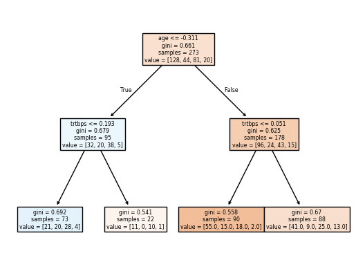

```python
X = ha[["trtbps", "chol", "age"]]
y = ha["cp"]


knn_model =Pipeline(
    [("scale", StandardScaler()),
    ("model", KNeighborsClassifier(n_neighbors=5))]
)

knn_model.fit(X, y)


dt_model =Pipeline(
    [("scale", StandardScaler()),
    ("model", DecisionTreeClassifier(max_depth=2))]
)

dt_model.fit(X, y)

plot_tree(dt_model.named_steps["model"], feature_names=["trtbps", "chol", "age"], filled=True)


lda  = LDA().fit(X, y)

print("KNN acc:", accuracy_score(y, knn_model.predict(X)))
print("Tree acc:", accuracy_score(y, dt_model.predict(X)))
print("LDA acc:", accuracy_score(y, lda.predict(X)))
```

## Q2: OvR

Create a new column in the `ha` dataset called `cp_is_3`, which is equal to `1` if the `cp` variable is equal to `3` and `0` otherwise.

Then, fit a Logistic Regression to predict this new target, and report the **F1 Score**.

Repeat for the other three `cp` categories. Which category was the OvR approach best at distinguishing?

```python
ha["cp_is_3"] = (ha["cp"] == 3) * 1
ha["cp_is_2"] = (ha["cp"] == 2) * 1
ha["cp_is_1"] = (ha["cp"] == 1) * 1
ha["cp_is_0"] = (ha["cp"] == 0) * 1

ha["cp"] = ha["cp"].astype("str")
```

```python
X = ha[["trtbps", "chol", "age"]]
y = ha["cp_is_3"]


logistic_model =Pipeline(
    [("scale", StandardScaler()),
    ("model", LogisticRegression())]
)

logistic_model.fit(X, y)

cross_val_score(logistic_model, X, y, cv=5, scoring="f1").mean()
```

```
np.float64(0.0)
```

```python
X = ha[["trtbps", "chol", "age"]]
y = ha["cp_is_0"]


logistic_model =Pipeline(
    [("scale", StandardScaler()),
    ("model", LogisticRegression())]
)

logistic_model.fit(X, y)

cross_val_score(logistic_model, X, y, cv=5, scoring="f1").mean()
```

```
np.float64(0.4624250522492891)
```

```python
X = ha[["trtbps", "chol", "age"]]
y = ha["cp_is_1"]


logistic_model =Pipeline(
    [("scale", StandardScaler()),
    ("model", LogisticRegression())]
)

logistic_model.fit(X, y)

cross_val_score(logistic_model, X, y, cv=5, scoring="f1").mean()
```

```
np.float64(0.0)
```

```python
X = ha[["trtbps", "chol", "age"]]
y = ha["cp_is_2"]


logistic_model =Pipeline(
    [("scale", StandardScaler()),
    ("model", LogisticRegression())]
)

logistic_model.fit(X, y)

cross_val_score(logistic_model, X, y, cv=5, scoring="f1").mean()
```

```
np.float64(0.0)
```

The only groups that had an F1 score was group 0, so I would say category 0 is the best at distinguishing.

## Q3: OvO

Reduce your dataset to only the `0` and `1` types of chest pain.

Then, fit a Logistic Regression to predict between the two groups, and report the **ROC-AUC**.

Repeat comparing category `0` to `2` and `3`. Which pair was the OvO approach best at distinguishing?

```python
ha_01 = ha[(ha["cp"] == "0") | (ha["cp"] == "1")]

X = ha_01[["trtbps", "chol", "age"]]
y = ha_01["cp"]


logistic_model =Pipeline(
    [("scale", StandardScaler()),
    ("model", LogisticRegression())]
)

logistic_model.fit(X, y)

cross_val_score(logistic_model, X, y, cv=5, scoring="roc_auc").mean()
```

```
np.float64(0.6016623931623932)
```

```python
ha_02 = ha[(ha["cp"] == "0") | (ha["cp"] == "2")]

X = ha_02[["trtbps", "chol", "age"]]
y = ha_02["cp"]


logistic_model =Pipeline(
    [("scale", StandardScaler()),
    ("model", LogisticRegression())]
)

logistic_model.fit(X, y)

cross_val_score(logistic_model, X, y, cv=5, scoring="roc_auc").mean()
```

```
np.float64(0.5593246606334841)
```

```python
ha_03 = ha[(ha["cp"] == "0") | (ha["cp"] == "3")]

X = ha_03[["trtbps", "chol", "age"]]
y = ha_03["cp"]


logistic_model =Pipeline(
    [("scale", StandardScaler()),
    ("model", LogisticRegression())]
)

logistic_model.fit(X, y)

cross_val_score(logistic_model, X, y, cv=5, scoring="roc_auc").mean()
```

```
np.float64(0.5585384615384615)
```

The comparison between 0 and 1 had the best ROC AUC score, so I would say that that comparison was the best at distinguishing between groups.